# MSCA 32003 Marketing Analytics Assignment 2

Michael N. Colella, Christopher Williams, Jonathan Williams

May 13, 2020

1. **Use journey or chocolate data from package conjoint. Perform the following analyses: (2 points)**
   1. Partworth estimation for all individuals separately
   2. Partworth estimation by combining all individual responses into an aggregate
   3. Partworth estimation by using linear mixed models. In this case, you should treat each individual as a separate group for defining the random effects
   4. Partworth estimation of the mixed effects models by using MCMChregress

**Data Exploration**

```r
library(conjoint)

# chocolate data from package conjoint
data(chocolate)

ls()
```

```
## [1] "clevn"  "cpref"  "cprefm" "cprof"  "csimp"
```

This data import is comprised of the following:

- clevn - vector of for the attributes’ levels (14 levels)
- cpref - vector of preferences
- cprefm - matrix of preferences (87 respondents and 16 profiles),
- cprof - matrix of profiles (5 attributes and 16 profiles)
- csimp - matrix of simulation profiles (5 attributes and 4 profiles)

```r
options(max.print=99999) # set to get all 87 to print
print(head(clevn))
```

```
##       levels
## 1       milk
## 2     walnut
## 3 delicaties
## 4       dark
## 5        low
## 6    average
```

The cholocate datset has 5 attributes with the following levels: kind (milk, walnut, delicaties, dark), price (low, average, high), packing (paperback, hardback), weight(light, middle, heavy), and calorie (little, much). This vector contains the levels.

```r
options(max.print=99999) # set to get all 87 to print
print(head(cpref))
```

```
##   pref
## 1   14
## 2   15
## 3    5
## 4    2
## 5    1
## 6   11
```

Each person is asked the utility or preference of the 16 profiles, there will be 87 people x 16 profiles = 1392 preferences.

```r
options(max.print=99999) # set to get all 87 to print
print(head(cprefm))
```

```
##   profile1 profile2 profile3 profile4 profile5 profile6 profile7 profile8
## 1       14       15        5        2        1       11        3       10
## 2       16       15        7       14        6        3       12        8
## 3        7        8        9       13       14        1       16        2
## 4        9       10       11       14       15        8        3        2
## 5        7        1        4       12       16        8       15        2
## 6       14       16       15        7        8        9       11       10
##   profile9 profile10 profile11 profile12 profile13 profile14 profile15
## 1       16        13        12         7         6         9         4
## 2        1         4        13         9         5        10        11
## 3        5         6         4        10        11         3        15
## 4        7         1         4         6         5        12        16
## 5        3         5        11        14        10         6        13
## 6       13        12         1         3         2         5         6
##   profile16
## 1         8
## 2         2
## 3        12
## 4        13
## 5         9
## 6         4
```

This dataset has already selected profiles or concepts that the people rated. A full factorial design would require 144 profiles (4 x 3 x 2 x 3 x 2). Hopefully, when these profiles were chosen in the experimental design process, orthoganility was maintained. With conjoint analysis, you only need a subset of the profiles to mantain orthogonality and predict all 144 profiles.

```r
options(max.print=99999) # set to get all 16 to print if needed
print(head(cprof))
```

```
##   kind price packing weight calorie
## 1    3     3       1      2       1
## 2    3     2       2      1       2
## 3    2     1       2      1       1
## 4    4     1       2      1       1
## 5    4     2       2      2       1
## 6    1     1       2      2       2
```

Dummy variables were not used as all the attribute level ranges are present. Since we are calculating coeffiecients and if dummy variables are used, you only really need 3 + 2 + 1 + 2 + 1 = 9 + intercept = 10 profiles.

```r
print(head(csimp))
```

```
##   kind price packing weight calorie
## 1    4     1       2      2       1
## 2    1     3       1      1       2
## 3    2     2       1      3       1
## 4    3     1       1      1       1
```

The chocolate dataset already has some profiles that were not presented to people to simulate preferences. These will be used in question 4 to calculate market shares estimates.

**Data Preparation**

Based on how the dataset provided with a given set of profiles, we will create our own design matrix with dummy variables.

```r
knitr::opts_chunk$set(echo = TRUE)
cprof.factor=data.frame(apply(cprof,2,factor))
contrasts(cprof.factor[,1])
```

```
##   2 3 4
## 1 0 0 0
## 2 1 0 0
## 3 0 1 0
## 4 0 0 1
```

```r
contrasts(cprof.factor[,2])
```

```
##   2 3
## 1 0 0
## 2 1 0
## 3 0 1
```

```r
contrasts(cprof.factor[,3])
```

```
##   2
## 1 0
## 2 1
```

```r
contrasts(cprof.factor[,4])
```

```
##   2 3
## 1 0 0
## 2 1 0
## 3 0 1
```

```r
contrasts(cprof.factor[,5])
```

```
##   2
## 1 0
## 2 1
```

```r
des.mm=model.matrix(~kind+price+packing+weight+calorie,data=cprof.factor,contrasts.arg=list(kind=contr.sum,price=contr.sum,packing=contr.sum,weight=contr.sum,calorie=contr.sum))
```

The Design matrix is coded using dummy variables. For instance, only 3 kinds, 2 prices, 1 packing, 2 weights, and 1 calorie are needed. This output reflects page 25 of the week 3 lecture slide although using a different dataset and the profiles were already chosen within the chocolate dataset. Therefore, we didn’t use the `optFederov` code to generate an orthogonal subset of profiles from the 144 possible profiles.

```r
des.mm[1:16,]
```

```
##    (Intercept) kind1 kind2 kind3 price1 price2 packing1 weight1 weight2
## 1            1     0     0     1     -1     -1        1       0       1
## 2            1     0     0     1      0      1       -1       1       0
## 3            1     0     1     0      1      0       -1       1       0
## 4            1    -1    -1    -1      1      0       -1       1       0
## 5            1    -1    -1    -1      0      1       -1       0       1
## 6            1     1     0     0      1      0       -1       0       1
## 7            1    -1    -1    -1     -1     -1        1       1       0
## 8            1     1     0     0      0      1        1      -1      -1
## 9            1     0     0     1      1      0       -1      -1      -1
## 10           1     0     0     1      1      0        1       1       0
## 11           1     1     0     0     -1     -1       -1       1       0
## 12           1     0     1     0      0      1        1       1       0
## 13           1     0     1     0     -1     -1       -1      -1      -1
## 14           1     1     0     0      1      0        1       1       0
```

[output cut: 19 more lines]

The correlation structure also looks good. Across levels, the correlation is low. This output reflects page 26 of the week 3 lecture slides, but using a different dataset.

```r
print(cor(des.mm))
```

```
##             (Intercept) kind1 kind2 kind3    price1    price2 packing1
## (Intercept)           1    NA    NA    NA        NA        NA       NA
## kind1                NA   1.0   0.5   0.5 0.0000000 0.0000000        0
## kind2                NA   0.5   1.0   0.5 0.0000000 0.0000000        0
## kind3                NA   0.5   0.5   1.0 0.0000000 0.0000000        0
## price1               NA   0.0   0.0   0.0 1.0000000 0.4264014        0
## price2               NA   0.0   0.0   0.0 0.4264014 1.0000000        0
## packing1             NA   0.0   0.0   0.0 0.0000000 0.0000000        1
## weight1              NA   0.0   0.0   0.0 0.0000000 0.0000000        0
## weight2              NA   0.0   0.0   0.0 0.0000000 0.0000000        0
## calorie1             NA   0.0   0.0   0.0 0.0000000 0.0000000        0
##               weight1   weight2 calorie1
## (Intercept)        NA        NA       NA
## kind1       0.0000000 0.0000000        0
## kind2       0.0000000 0.0000000        0
## kind3       0.0000000 0.0000000        0
## price1      0.0000000 0.0000000        0
## price2      0.0000000 0.0000000        0
## packing1    0.0000000 0.0000000        0
## weight1     1.0000000 0.4264014        0
## weight2     0.4264014 1.0000000        0
## calorie1    0.0000000 0.0000000        1
```

*Question 1, Part 1: Partworth estimation for all individuals separately*

```r
##Perform 87 regressions
##Then compute overall R-square

cprefm_mat=do.call(rbind,cprefm) #convert cprefm from list to matrix form
dim(cprefm_mat)
```

```
## [1] 16 87
```

```r
z=lm(cprefm_mat ~ des.mm)
summary(z)
```

```
## Response Y1 :
##
## Call:
## lm(formula = Y1 ~ des.mm)
##
## Residuals:
##    Min     1Q Median     3Q    Max
##  -0.50  -0.25   0.00   0.25   0.75
##
## Coefficients: (1 not defined because of singularities)
##                     Estimate Std. Error t value Pr(>|t|)
## (Intercept)        8.583e+00  1.596e-01  53.790 2.77e-09 ***
## des.mm(Intercept)         NA         NA      NA       NA
## des.mmkind1        2.000e+00  2.500e-01   8.000 0.000203 ***
## des.mmkind2       -2.000e+00  2.500e-01  -8.000 0.000203 ***
## des.mmkind3        6.000e+00  2.500e-01  24.000 3.44e-07 ***
## des.mmprice1      -6.528e-16  1.925e-01   0.000 1.000000
## des.mmprice2      -2.500e-01  2.257e-01  -1.108 0.310361
## des.mmpacking1     6.216e-17  1.443e-01   0.000 1.000000
## des.mmweight1     -3.333e-01  1.925e-01  -1.732 0.133975
## des.mmweight2     -8.333e-02  2.257e-01  -0.369 0.724605
## des.mmcalorie1    -1.000e+00  1.443e-01  -6.928 0.000448 ***
## ---
## Signif. codes:  0 '***' 0.001 '**' 0.01 '*' 0.05 '.' 0.1 ' ' 1
##
## Residual standard error: 0.5774 on 6 degrees of freedom
## Multiple R-squared:  0.9941, Adjusted R-squared:  0.9853
## F-statistic: 112.7 on 9 and 6 DF,  p-value: 5.374e-06
##
##
## Response Y2 :
##
## Call:
## lm(formula = Y2 ~ des.mm)
##
## Residuals:
##    Min     1Q Median     3Q    Max
## -5.750 -1.688  0.000  2.000  5.000
##
## Coefficients: (1 not defined because of singularities)
```

[output cut: 2553 more lines]

```
## des.mmkind1        2.000e+00  1.038e+00   1.926  0.10239
## des.mmkind2        2.000e+00  1.038e+00   1.926  0.10239
## des.mmkind3        2.000e+00  1.038e+00   1.926  0.10239
## des.mmprice1      -1.000e+00  7.993e-01  -1.251  0.25747
## des.mmprice2       5.388e-16  9.373e-01   0.000  1.00000
## des.mmpacking1    -2.500e-01  5.995e-01  -0.417  0.69117
## des.mmweight1     -3.333e-01  7.993e-01  -0.417  0.69117
## des.mmweight2      4.167e-01  9.373e-01   0.445  0.67223
## des.mmcalorie1    -2.500e+00  5.995e-01  -4.170  0.00588 **
## ---
## Signif. codes:  0 '***' 0.001 '**' 0.01 '*' 0.05 '.' 0.1 ' ' 1
##
## Residual standard error: 2.398 on 6 degrees of freedom
## Multiple R-squared:  0.8985, Adjusted R-squared:  0.7463
## F-statistic: 5.903 on 9 and 6 DF,  p-value: 0.02128
```

```r
z2=predict(lm(cprefm_mat ~ des.mm))
cor(as.vector(do.call(rbind,cprefm)),as.vector(z2))^2
```

```
## [1] 0.8758536
```

If we used the `conjoint` package built in function and look at the first person and its Beta values, you’ll see that the values match the previous results. For instance for the “kind” attribute levels, the milk attribute’s Beta in the below match the above at 2.00, etc. Even though dark is not listed in the above or what would be kind4, it will need to be -6.00 for the Betas for kind to equal to zero.

```r
print('Previous results - using provided R code, Betas for 1st person:', quote = FALSE)
```

```
## [1] Previous results - using provided R code, Betas for 1st person:
```

```r
summary(z)[0:1]
```

```
## Response Y1 :
##
## Call:
## lm(formula = Y1 ~ des.mm)
##
## Residuals:
##    Min     1Q Median     3Q    Max
##  -0.50  -0.25   0.00   0.25   0.75
##
## Coefficients: (1 not defined because of singularities)
##                     Estimate Std. Error t value Pr(>|t|)
## (Intercept)        8.583e+00  1.596e-01  53.790 2.77e-09 ***
## des.mm(Intercept)         NA         NA      NA       NA
## des.mmkind1        2.000e+00  2.500e-01   8.000 0.000203 ***
## des.mmkind2       -2.000e+00  2.500e-01  -8.000 0.000203 ***
## des.mmkind3        6.000e+00  2.500e-01  24.000 3.44e-07 ***
## des.mmprice1      -6.528e-16  1.925e-01   0.000 1.000000
## des.mmprice2      -2.500e-01  2.257e-01  -1.108 0.310361
## des.mmpacking1     6.216e-17  1.443e-01   0.000 1.000000
## des.mmweight1     -3.333e-01  1.925e-01  -1.732 0.133975
## des.mmweight2     -8.333e-02  2.257e-01  -0.369 0.724605
## des.mmcalorie1    -1.000e+00  1.443e-01  -6.928 0.000448 ***
## ---
## Signif. codes:  0 '***' 0.001 '**' 0.01 '*' 0.05 '.' 0.1 ' ' 1
##
## Residual standard error: 0.5774 on 6 degrees of freedom
## Multiple R-squared:  0.9941, Adjusted R-squared:  0.9853
## F-statistic: 112.7 on 9 and 6 DF,  p-value: 5.374e-06
```

```r
# caPartUtilities(y, x, z) – the function calculates the part-worths utility matrix of attribute levels in the cross-section of respondents and includes an intercept
options(max.print=99999) # set to get all 87 to print
partutilities=caPartUtilities(y=cpref,x=cprof,z=clevn)
print('Conjoint package - using builtin function, Betas for 1st person:', quote = FALSE)
```

```
## [1] Conjoint package - using builtin function, Betas for 1st person:
```

```r
print(partutilities[1,])
```

```
##  intercept       milk     walnut delicaties       dark        low    average
##      8.583      2.000     -2.000      6.000     -6.000      0.000     -0.250
##       high  paperback   hardback      light     middle      heavy     little
##      0.250      0.000      0.000     -0.333     -0.083      0.417     -1.000
##       much
##      1.000
```

*Question 1, Part 2: Partworth estimation by combining all individual responses into an aggregate*

With the aggregate model, we get a single value for the Betas which is expected.

```r
# caUtilities(y, x, z) - the function calculates part-worths utilities of attributes’ levels at an aggregated level
aggrutilities = caUtilities(y=cpref,x=cprof,z=clevn)
```

```
##
## Call:
## lm(formula = frml)
##
## Residuals:
##      Min       1Q   Median       3Q      Max
## -11,3305  -3,5546   0,4799   3,4799   9,8190
##
## Coefficients:
##                    Estimate Std. Error t value Pr(>|t|)
## (Intercept)         8,68487    0,12648  68,667  < 2e-16 ***
## factor(x$kind)1    -1,08908    0,19815  -5,496 4,62e-08 ***
## factor(x$kind)2    -0,73276    0,19815  -3,698 0,000226 ***
## factor(x$kind)3    -0,92241    0,19815  -4,655 3,55e-06 ***
## factor(x$price)1   -0,57088    0,15254  -3,743 0,000190 ***
## factor(x$price)2    0,11877    0,17887   0,664 0,506777
## factor(x$packing)1 -0,02874    0,11440  -0,251 0,801714
## factor(x$weight)1  -0,16858    0,15254  -1,105 0,269272
## factor(x$weight)2   0,17337    0,17887   0,969 0,332575
## factor(x$calorie)1 -0,64655    0,11440  -5,652 1,93e-08 ***
## ---
## Signif. codes:  0 '***' 0,001 '**' 0,01 '*' 0,05 '.' 0,1 ' ' 1
##
## Residual standard error: 4,268 on 1382 degrees of freedom
## Multiple R-squared:  0,1488, Adjusted R-squared:  0,1433
## F-statistic: 26,85 on 9 and 1382 DF,  p-value: < 2,2e-16
```

```r
print(aggrutilities)
```

```
##  [1]  8.684865900 -1.089080460 -0.732758621 -0.922413793  2.744252874
##  [6] -0.570881226  0.118773946  0.452107280 -0.028735632  0.028735632
## [11] -0.168582375  0.173371648 -0.004789272 -0.646551724  0.646551724
```

*Question 1, Part 3: Partworth estimation by using linear mixed models. In this case, you should treat each individual as a separate group for defining the random effects*

Before running the linear effects model, a file needs to be created that can be used by the `lme4` package. The Design Matrix is repeated 87 times since there are 87 people responding to the profiles. Since there are 16 profiles, there will be 16 x 87 or 1,392 rows. The preferences or “Rating” is included and is obviously 1,392 responses. Finally, a “respid” is include to keep track of each person and their responses.

```r
# building a file used for linear effects regression
d <- des.mm[1:16,2:10]
n1 <- 87
n2 <- 16
respid <- rep(1:n1, each = n2)
m1 <- do.call("rbind", replicate(n1, d, simplify = FALSE))
m2 <- cbind(m1, respid)
chocolatedata <- cbind(cpref, m2)
variable_names <- c("Rating","kind1","kind2","kind3","price1","price2","packing1","weight1",
                    "weight2","calorie1","respid")

colnames(chocolatedata) <- variable_names

# reset the index of the rows
rownames(chocolatedata) <- 1:(n1*n2)
print(chocolatedata[0:32,])
```

```
##    Rating kind1 kind2 kind3 price1 price2 packing1 weight1 weight2 calorie1
## 1      14     0     0     1     -1     -1        1       0       1        1
## 2      15     0     0     1      0      1       -1       1       0       -1
## 3       5     0     1     0      1      0       -1       1       0        1
## 4       2    -1    -1    -1      1      0       -1       1       0        1
## 5       1    -1    -1    -1      0      1       -1       0       1        1
## 6      11     1     0     0      1      0       -1       0       1       -1
## 7       3    -1    -1    -1     -1     -1        1       1       0       -1
## 8      10     1     0     0      0      1        1      -1      -1        1
## 9      16     0     0     1      1      0       -1      -1      -1       -1
## 10     13     0     0     1      1      0        1       1       0        1
## 11     12     1     0     0     -1     -1       -1       1       0       -1
## 12      7     0     1     0      0      1        1       1       0       -1
## 13      6     0     1     0     -1     -1       -1      -1      -1        1
## 14      9     1     0     0      1      0        1       1       0        1
```

[output cut: 51 more lines]

```r
# write out file to visually inspect output
write.csv(chocolatedata,"..\\chocolatedata.csv", row.names = TRUE)
```

Using the linear mix effects (`lme4`) package and its linear effects regression function (`lmer`) while specifying the variable that defines the subset groups of people as the `respid`, intercepts are generated for each person and each attribute. This accounts for both the individual and aggregate: a random effects model.

```r
require(lme4)
chocolatedata=read.csv(file="..\\chocolatedata.csv")
chocolatedata=chocolatedata[,-1]
z=lmer(Rating~kind1+kind2+kind3+price1+price2+packing1+weight1+weight2+calorie1+ (1+ kind1+kind2+kind3+price1+price2+packing1+weight1+weight2+calorie1|respid), control=lmerControl(optCtrl = list(maxfun=100000)), data=chocolatedata)
```

The below is the single aggregate regression equation or fixed effect:

```r
fixef(z)
```

```
## (Intercept)       kind1       kind2       kind3      price1      price2
##  8.68486590 -1.08908046 -0.73275862 -0.92241379 -0.57088123  0.11877395
##    packing1     weight1     weight2    calorie1
## -0.02873563 -0.16858238  0.17337165 -0.64655172
```

Each person has a different regression or random effect:

```r
head(ranef(z)$respid)
```

```
##   (Intercept)      kind1      kind2      kind3     price1       price2
## 1 -0.06965736  2.7691980 -0.9645635  6.3322746  0.2739071 -0.097047907
## 2  0.13604397  1.0297151 -1.6738134  1.1910521 -1.4479118 -0.025195036
## 3  0.03819088 -4.3359136  2.2981601 -0.9833782 -0.1747517 -0.002195698
## 4 -0.52334764 -0.7490089  0.7342913 -0.8548900  2.3883170 -0.251159928
## 5  0.07649172 -0.5646631  1.2948128 -3.3334083 -0.5202720 -0.274963146
## 6 -0.27675305 -0.9873552 -1.5838851  5.5312272  1.0172471  0.022181310
##      packing1      weight1      weight2   calorie1
## 1 -0.03684408  0.003354431 -0.338437740 -0.2679399
## 2  0.06608073  0.905514492 -0.741930257  0.6763436
## 3  0.03878129  0.023989798 -0.007731113  0.1841078
## 4 -0.24923382 -0.293151258  0.653345944  0.5299480
## 5 -0.10432891  0.214849493  0.213619731 -0.2266354
## 6 -0.04728162  0.092732818 -0.336095655  0.9566972
```

This is combination of the fixed and random effect or mixed effect and is a maximum likelyhood estimator:

```r
mixedeffect_part_worth <- coef(z)$respid
head(coef(z)$respid)
```

```
##   (Intercept)       kind1        kind2      kind3     price1      price2
## 1    8.615209  1.68011750 -1.697322106  5.4098608 -0.2969741  0.02172604
## 2    8.820910 -0.05936533 -2.406571983  0.2686383 -2.0187930  0.09357891
## 3    8.723057 -5.42499410  1.565401527 -1.9057920 -0.7456329  0.11657825
## 4    8.161518 -1.83808937  0.001532694 -1.7773038  1.8174358 -0.13238598
## 5    8.761358 -1.65374360  0.562054215 -4.2558221 -1.0911533 -0.15618920
## 6    8.408113 -2.07643567 -2.316643713  4.6088134  0.4463659  0.14095526
##      packing1     weight1    weight2   calorie1
## 1 -0.06557972 -0.16522794 -0.1650661 -0.9144916
## 2  0.03734510  0.73693212 -0.5685586  0.0297919
## 3  0.01004566 -0.14459258  0.1656405 -0.4624439
## 4 -0.27796945 -0.46173363  0.8267176 -0.1166037
## 5 -0.13306455  0.04626712  0.3869914 -0.8731871
## 6 -0.07601725 -0.07584956 -0.1627240  0.3101454
```

This is the $R^2$ for a better generalized model:

```r
cor(chocolatedata[,1],predict(z))^2
```

```
## [1] 0.8236706
```

Overall, this appear to have converged and worked, which is sometimes not the case.

*Question 1, Part 4: Partworth estimation of the mixed effects models by using MCMChregress*

```r
require(MCMCpack)
z=MCMCregress(Rating~kind1+kind2+kind3+price1+price2+packing1+weight1+weight2+calorie1, data=chocolatedata)

set.seed(1)
z=MCMChregress(fixed= Rating~kind1+kind2+kind3+price1+price2+packing1+weight1+weight2+calorie1, random = ~1+kind1+kind2+kind3+price1+price2+packing1+weight1+weight2+calorie1, group="respid", r=10,R=10*diag(10), data=chocolatedata)
```

```
##
## Running the Gibbs sampler. It may be long, keep cool :)
##
## **********:10.0%
## **********:20.0%
## **********:30.0%
## **********:40.0%
## **********:50.0%
## **********:60.0%
## **********:70.0%
## **********:80.0%
## **********:90.0%
## **********:100.0%
```

The below is the mixed effects simulated correlation using MCMC:

```r
cor(chocolatedata[,1],z$Y.pred)^2
```

```
## [1] 0.8697786
```

The below shows the 71st person’s mean and median mixed effects simulated values:

```r
colnames(z$mcmc)[1:87]
```

```
##  [1] "beta.(Intercept)" "beta.kind1"       "beta.kind2"       "beta.kind3"
##  [5] "beta.price1"      "beta.price2"      "beta.packing1"    "beta.weight1"
##  [9] "beta.weight2"     "beta.calorie1"    "b.(Intercept).1"  "b.(Intercept).10"
## [13] "b.(Intercept).11" "b.(Intercept).12" "b.(Intercept).13" "b.(Intercept).14"
## [17] "b.(Intercept).15" "b.(Intercept).16" "b.(Intercept).17" "b.(Intercept).18"
## [21] "b.(Intercept).19" "b.(Intercept).2"  "b.(Intercept).20" "b.(Intercept).21"
## [25] "b.(Intercept).22" "b.(Intercept).23" "b.(Intercept).24" "b.(Intercept).25"
## [29] "b.(Intercept).26" "b.(Intercept).27" "b.(Intercept).28" "b.(Intercept).29"
## [33] "b.(Intercept).3"  "b.(Intercept).30" "b.(Intercept).31" "b.(Intercept).32"
## [37] "b.(Intercept).33" "b.(Intercept).34" "b.(Intercept).35" "b.(Intercept).36"
## [41] "b.(Intercept).37" "b.(Intercept).38" "b.(Intercept).39" "b.(Intercept).4"
## [45] "b.(Intercept).40" "b.(Intercept).41" "b.(Intercept).42" "b.(Intercept).43"
## [49] "b.(Intercept).44" "b.(Intercept).45" "b.(Intercept).46" "b.(Intercept).47"
## [53] "b.(Intercept).48" "b.(Intercept).49" "b.(Intercept).5"  "b.(Intercept).50"
## [57] "b.(Intercept).51" "b.(Intercept).52" "b.(Intercept).53" "b.(Intercept).54"
## [61] "b.(Intercept).55" "b.(Intercept).56" "b.(Intercept).57" "b.(Intercept).58"
## [65] "b.(Intercept).59" "b.(Intercept).6"  "b.(Intercept).60" "b.(Intercept).61"
## [69] "b.(Intercept).62" "b.(Intercept).63" "b.(Intercept).64" "b.(Intercept).65"
## [73] "b.(Intercept).66" "b.(Intercept).67" "b.(Intercept).68" "b.(Intercept).69"
## [77] "b.(Intercept).7"  "b.(Intercept).70" "b.(Intercept).71" "b.(Intercept).72"
## [81] "b.(Intercept).73" "b.(Intercept).74" "b.(Intercept).75" "b.(Intercept).76"
## [85] "b.(Intercept).77" "b.(Intercept).78" "b.(Intercept).79"
```

```r
z$mcmc[1:87,grep(".71",colnames(z$mcmc),fixed=TRUE)]
```

```
##       b.(Intercept).71 b.kind1.71  b.kind2.71   b.kind3.71 b.price1.71
##  [1,]     -0.030301164 -4.9191818  0.69625570  2.303558145   1.7600350
##  [2,]     -0.096191749 -1.2366933 -0.56789058  1.689310347  -0.2851357
##  [3,]      1.090713278 -1.9756448 -0.25552715  1.884553976   0.3301974
##  [4,]     -0.157097541 -4.4530416 -1.40174648  1.042434279   0.4777491
##  [5,]     -0.385502098 -5.0208083  2.71099255 -0.818242024   0.9377780
##  [6,]      0.287736974 -2.1581825 -1.13039463 -1.124483506   1.8992073
##  [7,]     -0.050462580 -3.9362617  1.45458022  1.830382663   1.9435156
##  [8,]     -1.405524364 -3.3006705  3.19109264  0.540918724   2.3152082
##  [9,]      0.201470888 -1.7594997 -0.93635264 -0.294592230   2.2952096
## [10,]     -0.648430193 -4.6218209  0.82714705  2.687799157   1.6714484
## [11,]     -0.793841172 -3.4432415  0.51699535  0.290073682   1.8308266
## [12,]     -0.462698988 -3.6431490  1.16438387  0.105981805   0.6196384
## [13,]     -0.703386402 -3.7464676 -0.52454075  0.581836906   1.5799543
## [14,]      0.153629205 -2.2016421  1.39912671  2.292839592   0.3455101
```

[output cut: 161 more lines]

```r
apply(z$mcmc[,grep(".71",colnames(z$mcmc),fixed=TRUE)],2,mean)
```

```
## b.(Intercept).71       b.kind1.71       b.kind2.71       b.kind3.71
##       -0.1730393       -4.1296547        0.7911652        0.7915316
##      b.price1.71      b.price2.71    b.packing1.71     b.weight1.71
##        1.1759165       -0.1210458       -0.7981938       -0.3736290
##     b.weight2.71    b.calorie1.71
##        0.6403876       -0.1991142
```

```r
apply(z$mcmc[,grep(".71",colnames(z$mcmc),fixed=TRUE)],2,median)
```

```
## b.(Intercept).71       b.kind1.71       b.kind2.71       b.kind3.71
##       -0.1616584       -4.1297856        0.8549213        0.8130935
##      b.price1.71      b.price2.71    b.packing1.71     b.weight1.71
##        1.1469209       -0.1381609       -0.8231719       -0.3522593
##     b.weight2.71    b.calorie1.71
##        0.6293231       -0.2113093
```

2. **Assess performance of 1-4 in step (1) using 2 randomly selected profiles for each individual as “Holdout” profiles for each consumer. The winner should have the lowest error on the holdout profiles. (2 points)**

Dataset needs to have the same features inorder to test the ratings, therefore we will create a new dataframe to perform the train/test split to be consistent across the various individual, aggregate, and random effects models.

```r
n1 <- 87
n2 <- 16
respid <- rep(1:n1, each = n2)
m3 <- do.call("rbind", replicate(n1, cprof, simplify = FALSE))
m4 <- cbind(m3, respid)
chocolatedata2 <- cbind(cpref, m4)
variable_names2 <- c("Rating","kind","price","packing","weight",
                     "calorie","respid")
colnames(chocolatedata2) <- variable_names2

# reset the index of the rows
rownames(chocolatedata2) <- 1:(n1*n2)

# show the first 32 to see if respid is appending correctly
print(chocolatedata2[0:32,])
```

```
##    Rating kind price packing weight calorie respid
## 1      14    3     3       1      2       1      1
## 2      15    3     2       2      1       2      1
## 3       5    2     1       2      1       1      1
## 4       2    4     1       2      1       1      1
## 5       1    4     2       2      2       1      1
## 6      11    1     1       2      2       2      1
## 7       3    4     3       1      1       2      1
## 8      10    1     2       1      3       1      1
## 9      16    3     1       2      3       2      1
## 10     13    3     1       1      1       1      1
## 11     12    1     3       2      1       2      1
## 12      7    2     2       1      1       2      1
## 13      6    2     3       2      3       1      1
## 14      9    1     1       1      1       1      1
```

[output cut: 18 more lines]

Sampling a sequence from 1 to 16 87 times and putting these random pulls by person into the dataframe for later test/train split.

```r
# create a sequence of 16 numbers: 1, 2, 3, 4, 5, 6...
s <- seq(1,n2,1)
# create an empty array
rand <- vector()
for (i in 1:n1){
    # append sampled sequence
    # each sample will be in a ramdom order
    rand <- c(rand, sample(s))
    #rand <- c(rand, s)
}
#rand <- data.frame(rand)
#dim(rand)
chocolatedata3 <- cbind(chocolatedata2, rand)
variable_names3 <- c("Rating","kind","price","packing","weight",
                     "calorie","respid","rand_by_respid")
colnames(chocolatedata3) <- variable_names3

# show first 32 to valify that rand profile numbers were being applied to each respid correctly
print(chocolatedata3[0:32,])
```

```
##    Rating kind price packing weight calorie respid rand_by_respid
## 1      14    3     3       1      2       1      1              9
## 2      15    3     2       2      1       2      1              4
## 3       5    2     1       2      1       1      1              7
## 4       2    4     1       2      1       1      1              1
## 5       1    4     2       2      2       1      1              2
## 6      11    1     1       2      2       2      1             14
## 7       3    4     3       1      1       2      1             12
## 8      10    1     2       1      3       1      1              3
## 9      16    3     1       2      3       2      1             13
## 10     13    3     1       1      1       1      1              5
## 11     12    1     3       2      1       2      1             11
## 12      7    2     2       1      1       2      1             10
## 13      6    2     3       2      3       1      1              6
## 14      9    1     1       1      1       1      1             15
```

[output cut: 18 more lines]

Within each person’s 16 profile choices there is a random range of numbers from 1-16 with no repeating values. This will allow us to pull profiles randomly by person.

```r
train <- chocolatedata3[chocolatedata3$rand_by_respid < 15,]
test <- chocolatedata3[chocolatedata3$rand_by_respid >= 15,]
```

Dimensions of the entire dataset:

```r
dim(chocolatedata3)
```

```
## [1] 1392    8
```

Dimensions of the Train dataset:

```r
dim(train)
```

```
## [1] 1218    8
```

Dimensions of the Test dataset:

```r
dim(test)
```

```
## [1] 174   8
```

*Assess performance of 1 in step (1)*

Individual MSE:

```r
coeff_p1 <- matrix(nrow= 87, ncol = 6)
pred_p1 <- numeric(87)

for (i in 1:87){
    model_p1 <- lm(Rating~kind+price+packing+weight+calorie, data =train[train$respid==i,])
    coeff_p1[i,] <- model_p1$coefficient
    pred_p1[i] <- predict(model_p1, test[test$respid==i,])
}

mse_part1 <-mean(test$Rating-pred_p1)^2
print(mse_part1)
```

```
## [1] 0.06581374
```

*Assess performance of 2 in step (1)*

Aggregate MSE:

```r
model_p2 <- lm(Rating~kind+price+packing+weight+calorie, data =train)
model_p2_pred <- predict(model_p2, test)

mse_part2 <-mean(test$Rating-model_p2_pred)^2
print(mse_part2)
```

```
## [1] 0.0891542
```

*Assess performance of 3 in step (1)*

Random Effects MSE:

```r
require("lme4")

model_p3 =lmer(Rating~kind+price+packing+weight+calorie+(1+kind+price+packing+weight+calorie|respid), control=lmerControl(optCtrl = list(maxfun=100000)), data=train)
model_p3_pred <- predict(model_p3, test)
mse_part3 <- mean(test$Rating-model_p3_pred)^2
print(mse_part3)
```

```
## [1] 0.05496702
```

*Assess performance of 4 in step (1)*

MCMC MSE:

```r
require(MCMCpack)
set.seed(1)

model_p4 <- MCMChregress(fixed= Rating~kind+price+packing+weight+calorie, random= ~1+kind+price+packing+weight+calorie, group="respid", r=6,R=6*diag(6), data=train)
```

```
##
## Running the Gibbs sampler. It may be long, keep cool :)
##
## **********:10.0%
## **********:20.0%
## **********:30.0%
## **********:40.0%
## **********:50.0%
## **********:60.0%
## **********:70.0%
## **********:80.0%
## **********:90.0%
## **********:100.0%
```

```r
#mcmc_pred = matrix("NA", nrow=87, ncol = 6)
mcmc_pred = matrix("NA", nrow=87, ncol = 6)

for (i in 1:87){
    v1 <- model_p4$mcmc[,paste('b.(Intercept).', as.numeric(i), sep = '')]
    v2 <- model_p4$mcmc[,paste('b.kind.', as.numeric(i), sep = '')]
    v3 <- model_p4$mcmc[,paste('b.price.', as.numeric(i), sep = '')]
    v4 <- model_p4$mcmc[,paste('b.packing.', as.numeric(i), sep = '')]
    v5 <- model_p4$mcmc[,paste('b.weight.', as.numeric(i), sep = '')]
    v6 <- model_p4$mcmc[,paste('b.calorie.', as.numeric(i), sep = '')]

    mcmc_pred[i,1] <- mean(model_p4$mcmc[1:1000, 1]) + mean(v1)
    mcmc_pred[i,2] <- mean(model_p4$mcmc[1:1000, 2]) + mean(v2)
    mcmc_pred[i,3] <- mean(model_p4$mcmc[1:1000, 3]) + mean(v3)
    mcmc_pred[i,4] <- mean(model_p4$mcmc[1:1000, 4]) + mean(v4)
    mcmc_pred[i,5] <- mean(model_p4$mcmc[1:1000, 5]) + mean(v5)
    mcmc_pred[i,6] <- mean(model_p4$mcmc[1:1000, 6]) + mean(v6)
}

mcmc_pred <- apply(mcmc_pred, 2, as.numeric)

test_new <- cbind(test)

test_new$Pred <- mcmc_pred[,1]+test_new$kind*mcmc_pred[,2]+test_new$price*mcmc_pred[,3]
+test_new$packing*mcmc_pred[,4]+test_new$weight*mcmc_pred[,5]+test_new$calorie*mcmc_pred[,6]
```

```
##   [1]  3.0961971 -1.6314013  1.3747017  3.1135057  1.0655206  1.0457191
##   [7]  1.8351380  5.0898333  3.2327973  1.8558626  1.6292827  4.1962419
##  [13] -0.1560377  3.1188370  1.5173322  0.9917806  2.3146187  0.9495151
##  [19]  5.7161833  3.6392508  2.7764429  2.4005905  1.5735683  4.3361705
##  [25]  3.4544828  5.6118806  0.8242554  2.8634999  0.9119854  4.5428826
##  [31]  2.6298504  0.4059648  2.8183182 -0.2057648  0.2131038  2.9126425
##  [37]  0.7932657  2.4510449  3.6455639  0.7626285  1.6974331  6.9712171
##  [43]  1.7269200  2.6978222  1.2015715  0.8843283  1.5747782  2.3914148
##  [49]  2.8196616  1.9094738  2.1521934  0.3686903  3.5800768  3.8287225
##  [55]  2.1781733  1.9010196  4.5998199  2.6239690  3.4501179  2.6593857
##  [61]  0.4686408  2.2441892  0.9352459  2.4450401  1.4984114  1.5853866
##  [67]  0.3653229  5.5238520  2.5951511  1.7321655  2.2273131  1.5572173
##  [73]  0.4940970  3.8986814  5.4543883  7.6297669  1.2956382  4.4213995
##  [79]  2.5549999  4.7692572  1.6611069  7.3748820  2.2301091  2.3662453
##  [85]  7.6285142  2.1449620  7.3630516  6.7676811 -1.1756887  1.2798502
##  [91]  3.5701178  0.4381600  2.3823823  1.8351380  1.8092898  3.2327973
##  [97]  0.9755742  2.1940477  2.8926120  0.0650429  1.6513577  1.2129484
## [103]  1.2676237  2.4435735  0.6951864  7.0407816  1.2169722  4.5000645
## [109]  2.1054872  1.8009781  2.4590256  4.0189144  1.9990469  1.1017011
## [115]  0.7597435  2.2681166  5.6243614  2.2498773  1.3288042  4.2485860
## [121]  0.7760652 -0.5290052  2.9126425  2.4528799  2.1074771  4.9045249
## [127]  0.7626285  1.1655451  6.9712171  2.5114638  3.7950492  0.5038802
## [133]  1.5174730  1.3778410  1.7052863  6.0811302  1.6351487  3.2341880
## [139]  0.2002273  7.4627380  3.4725962  3.4535067  3.8711093  4.2992279
## [145]  4.3134032  3.0489463  1.4359582  0.3572163  0.1267591  1.8672294
## [151]  1.3932978  2.6937639  1.3375047  0.1356800  4.6945867  1.2144667
## [157]  2.2786380  3.4145098  3.1144347  0.7215749  5.4300865  4.3365025
## [163]  7.2160732  1.8859156  4.9626105  4.2696067  2.4461491  1.8367301
## [169]  2.9133935  2.5676854  2.0751470  7.0671897  2.1449620  7.5556995
```

```r
mse_part4 = mean(as.numeric(test_new$Rating)-test_new$Pred)^2

print(mse_part4)
```

```
## [1] 7.456859
```

3. **Perform cluster analysis of each individual’s partworths to define Benefit segments. For this purpose, use the partworths from steps 1,3, or 4 that has the best predictions for the holdout data from step 2. (2 points)**

Based on the question 2, the random effects model performed the best, and we will use its partworths. This is also the most general model. The linear mix effects (`lme4`) package did converge on a solution. Surprisingly, the MCMC model which should similute the outcome of a random effects model had a higher MSE score.

```r
# variable saved earlier
randomeffect_part_worth1 <- cbind(mixedeffect_part_worth)
# verify that it's a deep copy
#tracemem(randomeffect_part_worth1)==tracemem(mixedeffect_part_worth)
print(head(randomeffect_part_worth1))
```

```
##   (Intercept)       kind1        kind2      kind3     price1      price2
## 1    8.615209  1.68011750 -1.697322106  5.4098608 -0.2969741  0.02172604
## 2    8.820910 -0.05936533 -2.406571983  0.2686383 -2.0187930  0.09357891
## 3    8.723057 -5.42499410  1.565401527 -1.9057920 -0.7456329  0.11657825
## 4    8.161518 -1.83808937  0.001532694 -1.7773038  1.8174358 -0.13238598
## 5    8.761358 -1.65374360  0.562054215 -4.2558221 -1.0911533 -0.15618920
## 6    8.408113 -2.07643567 -2.316643713  4.6088134  0.4463659  0.14095526
##      packing1     weight1    weight2   calorie1
## 1 -0.06557972 -0.16522794 -0.1650661 -0.9144916
## 2  0.03734510  0.73693212 -0.5685586  0.0297919
## 3  0.01004566 -0.14459258  0.1656405 -0.4624439
## 4 -0.27796945 -0.46173363  0.8267176 -0.1166037
## 5 -0.13306455  0.04626712  0.3869914 -0.8731871
## 6 -0.07601725 -0.07584956 -0.1627240  0.3101454
```

Visualization 1 of Elbow Chart:

```r
require(tidyverse)
```

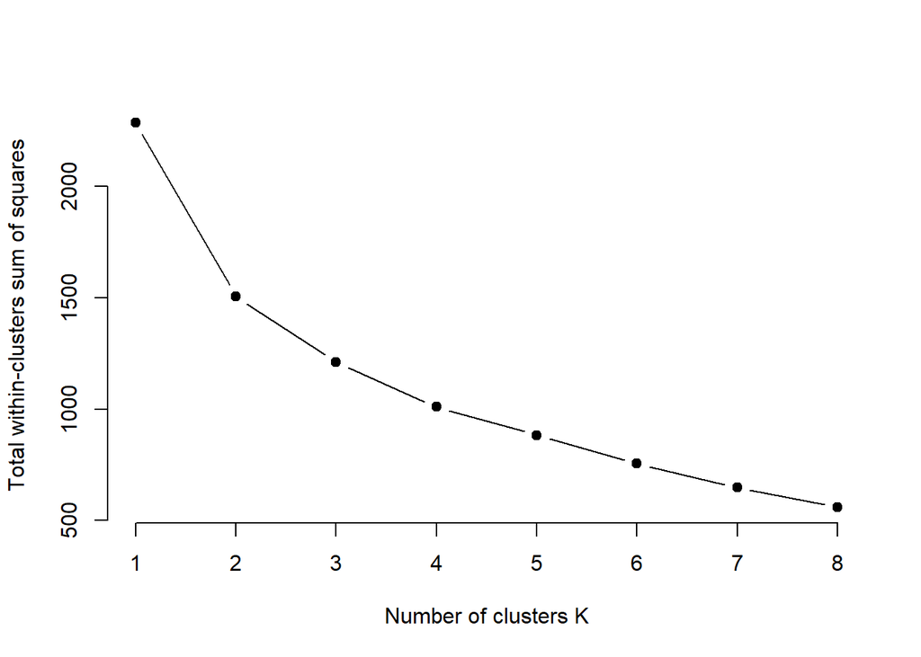

```r
# saved earlier
set.seed(76)

# function to compute total within-cluster sum of square
wss <- function(k) {
  kmeans(randomeffect_part_worth1, k, nstart = 10 )$tot.withinss
}

# Compute and plot wss for k = 1 to k = 8
k.values <- 1:8

# extract wss for 2-15 clusters
wss_values <- map_dbl(k.values, wss)

plot(k.values, wss_values,
       type="b", pch = 19, frame = FALSE,
       xlab="Number of clusters K",
       ylab="Total within-clusters sum of squares")
```

Visualization of Elbow Chart:

```r
require(factoextra)
```

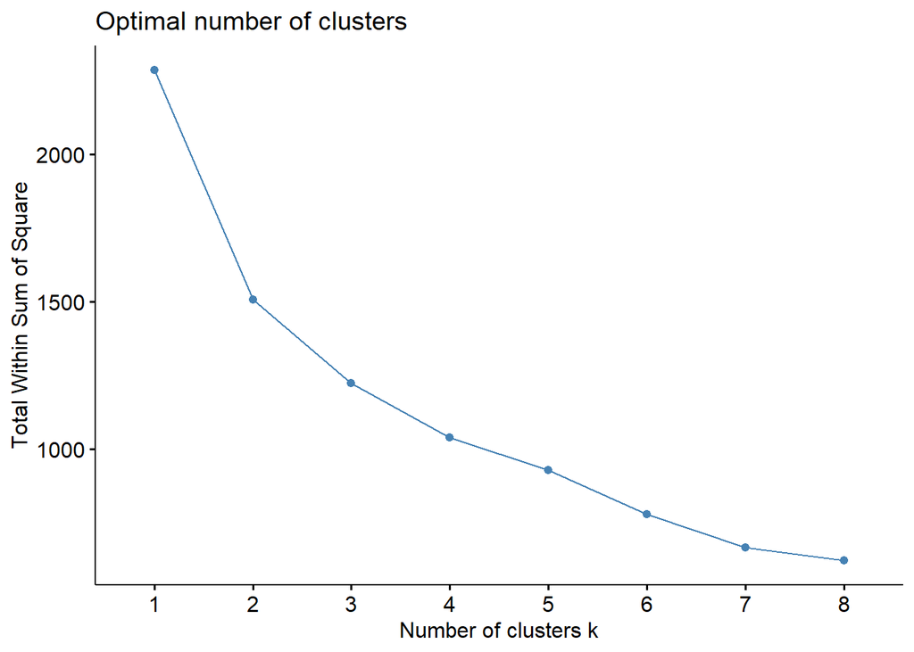

```r
set.seed(76)

fviz_nbclust(randomeffect_part_worth1, kmeans, k.max = 8, method = "wss")
```

Based on the two elbow chart visuals, 4 clusters will be used. With so few people, as the the cluster size gets larger these clusters will mimic more like individuals.

```r
# Compute k-means clustering with k = 2
set.seed(76)
clusters <- kmeans(randomeffect_part_worth1, 4, nstart = 20)
print(clusters)
```

```
## K-means clustering with 4 clusters of sizes 29, 18, 14, 26
##
## Cluster means:
##   (Intercept)     kind1      kind2     kind3     price1      price2    packing1
## 1    8.760861 -2.793192  0.4810727 -1.170188 -0.8176105 -0.04957795 -0.09338347
## 2    8.594405  1.834320 -2.8166440 -3.382289 -0.3622959  0.17165776 -0.05459231
## 3    8.567334  1.207243  2.3002602 -3.972649 -0.2323583  0.13256331  0.06062596
## 4    8.726015 -2.448714 -2.2771215  2.699374 -0.6223699  0.26251415  0.01315457
##       weight1     weight2   calorie1
## 1 -0.22685906  0.34047542 -1.1814867
## 2 -0.01517429  0.26497362 -0.2192274
## 3 -0.03623730  0.16667763 -0.4374616
## 4 -0.28104979 -0.07282561 -0.4583203
##
## Clustering vector:
##  1  2  3  4  5  6  7  8  9 10 11 12 13 14 15 16 17 18 19 20 21 22 23 24 25 26
##  4  4  1  1  1  4  1  3  2  2  3  4  1  4  4  2  4  2  1  4  1  2  2  1  1  2
## 27 28 29 30 31 32 33 34 35 36 37 38 39 40 41 42 43 44 45 46 47 48 49 50 51 52
##  3  4  4  2  3  1  4  1  4  3  3  4  3  4  2  1  2  1  4  4  1  4  3  2  4  4
## 53 54 55 56 57 58 59 60 61 62 63 64 65 66 67 68 69 70 71 72 73 74 75 76 77 78
##  1  3  4  4  1  1  1  4  1  4  1  2  4  2  4  3  4  2  1  2  1  3  3  1  1  1
## 79 80 81 82 83 84 85 86 87
##  2  3  1  1  3  2  1  2  1
##
## Within cluster sum of squares by cluster:
## [1] 310.2765 176.2576 160.4193 361.4090
##  (between_SS / total_SS =  55.9 %)
##
## Available components:
##
## [1] "cluster"      "centers"      "totss"        "withinss"     "tot.withinss"
## [6] "betweenss"    "size"         "iter"         "ifault"
```

Plot on two dimensions:

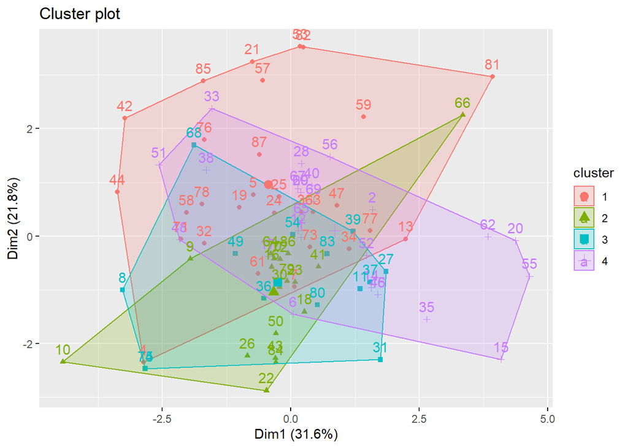

```r
fviz_cluster(clusters, data = randomeffect_part_worth1)
```

Appending the cluster information to the people and will be used to in question 5:

```r
randomeffect_part_worth1$BenefitSegments <- as.factor(clusters$cluster)

print(head(randomeffect_part_worth1))
```

```
##   (Intercept)       kind1        kind2      kind3     price1      price2
## 1    8.615209  1.68011750 -1.697322106  5.4098608 -0.2969741  0.02172604
## 2    8.820910 -0.05936533 -2.406571983  0.2686383 -2.0187930  0.09357891
## 3    8.723057 -5.42499410  1.565401527 -1.9057920 -0.7456329  0.11657825
## 4    8.161518 -1.83808937  0.001532694 -1.7773038  1.8174358 -0.13238598
## 5    8.761358 -1.65374360  0.562054215 -4.2558221 -1.0911533 -0.15618920
## 6    8.408113 -2.07643567 -2.316643713  4.6088134  0.4463659  0.14095526
##      packing1     weight1    weight2   calorie1 BenefitSegments
## 1 -0.06557972 -0.16522794 -0.1650661 -0.9144916               4
## 2  0.03734510  0.73693212 -0.5685586  0.0297919               4
## 3  0.01004566 -0.14459258  0.1656405 -0.4624439               1
## 4 -0.27796945 -0.46173363  0.8267176 -0.1166037               1
## 5 -0.13306455  0.04626712  0.3869914 -0.8731871               1
## 6 -0.07601725 -0.07584956 -0.1627240  0.3101454               4
```

4. **Build a simulator that takes as input 4 or 5 input concepts, and produces market share estimates. Function caLogit can be used from package conjoint (2 points)**

As mentioned prior in the “Data Exploration” section, the chocolate dataset already has some profiles that were not presented to people. These will be used in this question to calculate market shares estimates.

```r
print(head(csimp))
```

```
##   kind price packing weight calorie
## 1    4     1       2      2       1
## 2    1     3       1      1       2
## 3    2     2       1      3       1
## 4    3     1       1      1       1
```

In using the `caLogit` function, we are able to calculate the market share for each of the 4 concepts. In our case we chose concepts that were not part of the 16 concepts presented to the 87 people. The market share estimations will sum to 100% as if those are the concepts available to the 87 people based on their preferences on the original 16 profiles.

```r
simulator = caLogit(csimp, y=cpref,x=cprof)
print(simulator)
```

```
## [1] 49.81532 25.20706 12.65507 12.32256
```

5. **Summarize Segmentation results – Top 5 concepts for each segment. Provide attribute importance rankings for each segment. (2 points)**

```r
dim(randomeffect_part_worth1)
```

```
## [1] 87 11
```

```r
print(head(randomeffect_part_worth1))
```

```
##   (Intercept)       kind1        kind2      kind3     price1      price2
## 1    8.615209  1.68011750 -1.697322106  5.4098608 -0.2969741  0.02172604
## 2    8.820910 -0.05936533 -2.406571983  0.2686383 -2.0187930  0.09357891
## 3    8.723057 -5.42499410  1.565401527 -1.9057920 -0.7456329  0.11657825
## 4    8.161518 -1.83808937  0.001532694 -1.7773038  1.8174358 -0.13238598
## 5    8.761358 -1.65374360  0.562054215 -4.2558221 -1.0911533 -0.15618920
## 6    8.408113 -2.07643567 -2.316643713  4.6088134  0.4463659  0.14095526
##      packing1     weight1    weight2   calorie1 BenefitSegments
## 1 -0.06557972 -0.16522794 -0.1650661 -0.9144916               4
## 2  0.03734510  0.73693212 -0.5685586  0.0297919               4
## 3  0.01004566 -0.14459258  0.1656405 -0.4624439               1
## 4 -0.27796945 -0.46173363  0.8267176 -0.1166037               1
## 5 -0.13306455  0.04626712  0.3869914 -0.8731871               1
## 6 -0.07601725 -0.07584956 -0.1627240  0.3101454               4
```

```r
randomeffect_part_worth2 <- cbind(randomeffect_part_worth1)

# coefficients will sum to 0
# adding the missing variable
randomeffect_part_worth2$kind4 <- -(randomeffect_part_worth2$kind1+randomeffect_part_worth2$kind2+randomeffect_part_worth2$kind3)
randomeffect_part_worth2$price3 <- -(randomeffect_part_worth2$price1+randomeffect_part_worth2$price2)
randomeffect_part_worth2$packing2 <- -(randomeffect_part_worth2$packing1)
randomeffect_part_worth2$weight3 <- -(randomeffect_part_worth2$weight1+randomeffect_part_worth2$weight2)
randomeffect_part_worth2$calorie2 <- -(randomeffect_part_worth2$calorie1)

# create an empty arrays
kind_attri_imp <- vector()
price_attri_imp <- vector()
packing_attri_imp <- vector()
weight_attri_imp <- vector()
calorie_attri_imp <- vector()
for (i in 1:nrow(randomeffect_part_worth2)){
  kind_attri_imp <- c(kind_attri_imp, sum(abs(range(randomeffect_part_worth2[i,]$kind1,randomeffect_part_worth2[i,]$kind2,randomeffect_part_worth2[i,]$kind3, randomeffect_part_worth2[i,]$kind4))))

  price_attri_imp <- c(price_attri_imp, sum(abs(range(randomeffect_part_worth2[i,]$price1,randomeffect_part_worth2[i,]$price2, randomeffect_part_worth2[i,]$price3))))

  packing_attri_imp <- c(packing_attri_imp, sum(abs(range(randomeffect_part_worth2[i,]$packing1,randomeffect_part_worth2[i,]$packing2))))

  weight_attri_imp <- c(weight_attri_imp, sum(abs(range(randomeffect_part_worth2[i,]$weight1,randomeffect_part_worth2[i,]$weight2, randomeffect_part_worth2[i,]$weight3))))

  calorie_attri_imp <- c(calorie_attri_imp, sum(abs(range(randomeffect_part_worth2[i,]$calorie1, randomeffect_part_worth2[i,]$calorie2))))

}
randomeffect_part_worth3 <- cbind(randomeffect_part_worth2, kind_attri_imp, price_attri_imp, packing_attri_imp, weight_attri_imp, calorie_attri_imp)
variable_names4 <- c("(Intercept)", "kind1", "kind2", "kind3", "price1", "price2", "packing1", "weight1", "weight2", "calorie1", "BenefitSegments", "kind4", "price3", "packing2", "weight3", "calorie2", "kind_attri_imp", "price_attri_imp", "packing_attri_imp", "weight_attri_imp", "calorie_attri_imp")

colnames(randomeffect_part_worth3) <- variable_names4

randomeffect_part_worth3$overall_attri_imp = randomeffect_part_worth3$kind_attri_imp+randomeffect_part_worth3$price_attri_imp+randomeffect_part_worth3$packing_attri_imp+randomeffect_part_worth3$weight_attri_imp+randomeffect_part_worth3$calorie_attri_imp

print(head(randomeffect_part_worth3))
```

```
##   (Intercept)       kind1        kind2      kind3     price1      price2
## 1    8.615209  1.68011750 -1.697322106  5.4098608 -0.2969741  0.02172604
## 2    8.820910 -0.05936533 -2.406571983  0.2686383 -2.0187930  0.09357891
## 3    8.723057 -5.42499410  1.565401527 -1.9057920 -0.7456329  0.11657825
## 4    8.161518 -1.83808937  0.001532694 -1.7773038  1.8174358 -0.13238598
## 5    8.761358 -1.65374360  0.562054215 -4.2558221 -1.0911533 -0.15618920
## 6    8.408113 -2.07643567 -2.316643713  4.6088134  0.4463659  0.14095526
##      packing1     weight1    weight2   calorie1 BenefitSegments     kind4
## 1 -0.06557972 -0.16522794 -0.1650661 -0.9144916               4 -5.392656
## 2  0.03734510  0.73693212 -0.5685586  0.0297919               4  2.197299
## 3  0.01004566 -0.14459258  0.1656405 -0.4624439               1  5.765385
## 4 -0.27796945 -0.46173363  0.8267176 -0.1166037               1  3.613860
## 5 -0.13306455  0.04626712  0.3869914 -0.8731871               1  5.347512
## 6 -0.07601725 -0.07584956 -0.1627240  0.3101454               4 -0.215734
##       price3    packing2     weight3   calorie2 kind_attri_imp price_attri_imp
## 1  0.2752481  0.06557972  0.33029404  0.9144916      10.802517       0.5722222
## 2  1.9252141 -0.03734510 -0.16837351 -0.0297919       4.603871       3.9440071
## 3  0.6290547 -0.01004566 -0.02104796  0.4624439      11.190379       1.3746876
## 4 -1.6850498  0.27796945 -0.36498396  0.1166037       5.451950       3.5024856
## 5  1.2473425  0.13306455 -0.43325850  0.8731871       9.603334       2.3384957
## 6 -0.5873212  0.07601725  0.23857356 -0.3101454       6.925457       1.0336871
##   packing_attri_imp weight_attri_imp calorie_attri_imp overall_attri_imp
## 1        0.13115943        0.4955220         1.8289832         13.830404
## 2        0.07469021        1.3054907         0.0595838          9.987643
## 3        0.02009131        0.3102331         0.9248878         13.820278
## 4        0.55593891        1.2884512         0.2332074         11.032033
## 5        0.26612909        0.8202499         1.7463742         14.774583
## 6        0.15203450        0.4012976         0.6202909          9.132767
```

```r
# Sort by BenefitSegments and then by overall attribute importance

df <- randomeffect_part_worth3[order(randomeffect_part_worth3$BenefitSegments, -randomeffect_part_worth3$overall_attri_imp),]
df <- subset(df, select = c(BenefitSegments, kind_attri_imp, price_attri_imp, packing_attri_imp, weight_attri_imp, calorie_attri_imp, overall_attri_imp))

BenefitSegment <- split(df, df$BenefitSegments)
```

Top profiles for cluster 1:

```r
print(head(BenefitSegment[[1]]))
```

```
##    BenefitSegments kind_attri_imp price_attri_imp packing_attri_imp
## 85               1       4.376221       2.9211732        0.59304190
## 44               1       8.366924       2.2163659        1.26633834
## 21               1       4.875483       4.8804498        0.52240913
## 71               1      10.617406       0.8056884        0.60225054
## 25               1      11.223537       1.2664338        0.07476636
## 5                1       9.603334       2.3384957        0.26612909
##    weight_attri_imp calorie_attri_imp overall_attri_imp
## 85        1.2440818          6.061857          15.19637
## 44        1.7416499          1.489623          15.08090
## 21        0.7011753          3.940389          14.91991
## 71        1.1699369          1.694496          14.88978
## 25        0.6044828          1.690676          14.85990
## 5         0.8202499          1.746374          14.77458
```

Top profiles for cluster 2:

```r
print(head(BenefitSegment[[2]]))
```

```
##    BenefitSegments kind_attri_imp price_attri_imp packing_attri_imp
## 70               2       11.28267       1.0510864       0.002745618
## 64               2       11.09411       1.1805549       0.042684347
## 86               2       10.98031       1.0380832       0.122612624
## 16               2       11.35280       1.4708076       0.120398354
## 23               2       11.31760       1.5572179       0.015897799
## 30               2       11.31378       0.6877845       0.012578742
##    weight_attri_imp calorie_attri_imp overall_attri_imp
## 70        0.7593695        1.62028662          14.71616
## 64        0.7540056        1.59361264          14.66497
## 86        0.5742885        1.57953014          14.29482
## 16        0.7126937        0.57508797          14.23179
## 23        0.6002579        0.04815606          13.53913
## 30        0.6308639        0.65035366          13.29536
```

Top profiles for cluster 3:

```r
print(head(BenefitSegment[[3]]))
```

```
##    BenefitSegments kind_attri_imp price_attri_imp packing_attri_imp
## 68               3       8.021928       2.2655160         0.3968261
## 54               3      10.545677       1.1965901         0.2009898
## 49               3      10.581545       0.1708596         0.1627386
## 27               3      10.688710       1.5936495         0.6886673
## 11               3      11.116172       1.2839447         0.4884247
## 83               3      10.525194       1.8919266         0.2545983
##    weight_attri_imp calorie_attri_imp overall_attri_imp
## 68        1.2853539         4.0905679          16.06019
## 54        0.1496063         1.9366832          14.02955
## 49        1.2468074         1.8048094          13.96676
## 27        0.5872595         0.3342837          13.89257
## 11        0.5002618         0.3614920          13.75029
## 83        0.8054162         0.2304808          13.70762
```

Top profiles for cluster 4:

```r
print(head(BenefitSegment[[4]]))
```

```
##    BenefitSegments kind_attri_imp price_attri_imp packing_attri_imp
## 51               4       9.359269        1.741538        1.04770802
## 56               4       9.265008        2.243477        0.01649722
## 28               4      10.843964        1.199534        0.14274177
## 29               4      11.263035        1.206809        0.14174475
## 60               4      11.263035        1.206809        0.14174475
## 40               4      11.312074        1.867094        0.19682735
##    weight_attri_imp calorie_attri_imp overall_attri_imp
## 51        1.4034454          2.773395          16.32536
## 56        0.8434711          3.124386          15.49284
## 28        0.6818781          2.575982          15.44410
## 29        0.5691105          1.733062          14.91376
## 60        0.5691105          1.733062          14.91376
## 40        0.4241756          1.059379          14.85955
```